# R’s data.table

> The **source of this tutorial**, including the example datasets, is available [here on GitHub](https://github.com/ethen8181/machine-learning/blob/master/R/data_table)

# SQL Joins

For joining data.tables, the basic syntax are:

| JOIN type | DT syntax | data.table::merge() syntax |
| --- | --- | --- |
| INNER | X[Y, nomatch = 0] | merge(X, Y, all = FALSE) |
| LEFT OUTER | Y[X] | merge(X, Y, all.x = TRUE) |
| RIGHT OUTER | X[Y] | merge(X, Y, all.y = TRUE) |
| FULL OUTER | - | merge(X, Y, all = TRUE) |

The example data consists of the following two tables:

```r
library(knitr)
library(data.table)
setwd("/Users/ethen/machine-learning/R/data_table")

employees   <- fread("data/employees.csv")
departments <- fread("data/departments.csv")
knitr::kable( employees, caption = "Table Employees" )
```

Table Employees

| Employee | EmployeeName | Department | Salary |
| --- | --- | --- | --- |
| 1 | Alice | 11 | 800 |
| 2 | Bob | 11 | 600 |
| 3 | Carla | 12 | 900 |
| 4 | Daniel | 12 | 1000 |
| 5 | Evelyn | 13 | 800 |
| 6 | Ferdinand | 21 | 700 |

```r
knitr::kable( departments, caption = "Table Departments" )
```

Table Departments

| Department | DepartmentName | Manager |
| --- | --- | --- |
| 11 | Production | 1 |
| 12 | Sales | 4 |
| 13 | Marketing | 5 |
| 14 | Research | NA |

## Inner Join

*Figure linked from [Pinal Dave](http://blog.sqlauthority.com/2009/04/13/sql-server-introduction-to-joins-basic-of-joins/)*

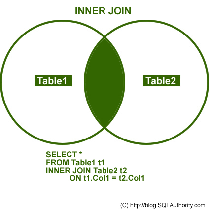

**the *INNER JOIN* returns the rows with a match in both tables**

```r
# inner join with merge
merge( employees, departments, by = "Department" )
```

```
##    Department Employee EmployeeName Salary DepartmentName Manager
## 1:         11        1        Alice    800     Production       1
## 2:         11        2          Bob    600     Production       1
## 3:         12        3        Carla    900          Sales       4
## 4:         12        4       Daniel   1000          Sales       4
## 5:         13        5       Evelyn    800      Marketing       5
```

```r
# inner join with keys
# set the keys of the tables to represent the by:
setkey( employees, Department )
setkey( departments, Department )
# equivalent to setkeyv( departments, "Department" )

# note that you only need to set the keys once
# you can confirm if it works with
key( employees)
```

```
## [1] "Department"
```

```r
# perform the join,
# nomatch 0 means no rows will be returned
# from not matched rows from the Right table
employees[ departments, nomatch = 0 ]
```

```
##    Employee EmployeeName Department Salary DepartmentName Manager
## 1:        1        Alice         11    800     Production       1
## 2:        2          Bob         11    600     Production       1
## 3:        3        Carla         12    900          Sales       4
## 4:        4       Daniel         12   1000          Sales       4
## 5:        5       Evelyn         13    800      Marketing       5
```

As we’ll see later, without anything else, `TABLE_X[TABLE_Y]` returns a **right outer join**; setting `nomatch=0` returns a **inner join**.

**note:**

> Employee #6, Ferdinand, has not been returned, as he’s in a yet to be created department 21. Neither has department #14, Research, as there are no employees.

## Left Outer Join

*Figure linked from [Pinal Dave](http://blog.sqlauthority.com/2009/04/13/sql-server-introduction-to-joins-basic-of-joins/)*

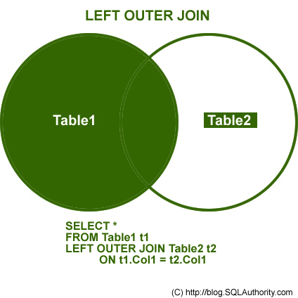

**the *LEFT OUTER JOIN* returns all the rows from the left table, filling in matched columns (or NA) from the right table**

```r
# left join with merge, notice that the column's ordering is different
merge( employees, departments, by = "Department", all.x = TRUE )
```

```
##    Department Employee EmployeeName Salary DepartmentName Manager
## 1:         11        1        Alice    800     Production       1
## 2:         11        2          Bob    600     Production       1
## 3:         12        3        Carla    900          Sales       4
## 4:         12        4       Daniel   1000          Sales       4
## 5:         13        5       Evelyn    800      Marketing       5
## 6:         21        6    Ferdinand    700             NA      NA
```

```r
departments[employees]
```

```
##    Department DepartmentName Manager Employee EmployeeName Salary
## 1:         11     Production       1        1        Alice    800
## 2:         11     Production       1        2          Bob    600
## 3:         12          Sales       4        3        Carla    900
## 4:         12          Sales       4        4       Daniel   1000
## 5:         13      Marketing       5        5       Evelyn    800
## 6:         21             NA      NA        6    Ferdinand    700
```

**note:**

> Employee #6, Ferdinand, has been returned with department name as NA.  
> Department #14, Research, has not been returned.

## Right Outer Join

*Figure linked from [Pinal Dave](http://blog.sqlauthority.com/2009/04/13/sql-server-introduction-to-joins-basic-of-joins/)*

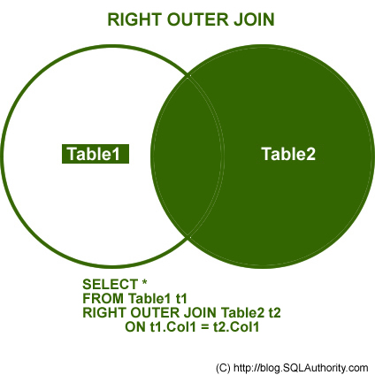

**the *RIGHT OUTER JOIN* returns all the rows from the right table, filling in matched columns (or else NA) from the left table**

```r
# right join with merge
merge( employees, departments, by = "Department", all.y = TRUE )
```

```
##    Department Employee EmployeeName Salary DepartmentName Manager
## 1:         11        1        Alice    800     Production       1
## 2:         11        2          Bob    600     Production       1
## 3:         12        3        Carla    900          Sales       4
## 4:         12        4       Daniel   1000          Sales       4
## 5:         13        5       Evelyn    800      Marketing       5
## 6:         14       NA           NA     NA       Research      NA
```

```r
employees[departments]
```

```
##    Employee EmployeeName Department Salary DepartmentName Manager
## 1:        1        Alice         11    800     Production       1
## 2:        2          Bob         11    600     Production       1
## 3:        3        Carla         12    900          Sales       4
## 4:        4       Daniel         12   1000          Sales       4
## 5:        5       Evelyn         13    800      Marketing       5
## 6:       NA           NA         14     NA       Research      NA
```

```r
# we can also do a not matched with !
# returning the rows in the employees table that are not in the
# department table
employees[!departments]
```

```
##    Employee EmployeeName Department Salary
## 1:        6    Ferdinand         21    700
```

## Full Outer Join

*Figure linked from [Pinal Dave](http://blog.sqlauthority.com/2009/04/13/sql-server-introduction-to-joins-basic-of-joins/)*

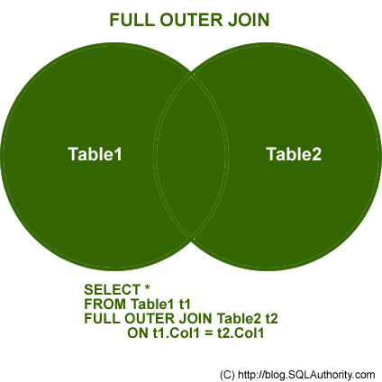

**the *FULL OUTER JOIN* returns all the rows from both tables, filling in matched columns (or else NA)**

```r
merge( employees, departments, by = "Department", all = TRUE )
```

```
##    Department Employee EmployeeName Salary DepartmentName Manager
## 1:         11        1        Alice    800     Production       1
## 2:         11        2          Bob    600     Production       1
## 3:         12        3        Carla    900          Sales       4
## 4:         12        4       Daniel   1000          Sales       4
## 5:         13        5       Evelyn    800      Marketing       5
## 6:         14       NA           NA     NA       Research      NA
## 7:         21        6    Ferdinand    700             NA      NA
```

# Other Tips and Tricks

## `.SD` and `.N`

First `.SD` refers to the subset of data for each group. The example below gets the sum of y and z and the number of rows (using `.N`) in each group while grouped by x.

```r
DT <- data.table( x = sample( 1:2, 7, replace = TRUE ),
                  y = sample( 1:13,7 ),
                  z = sample( 1:14,7 ) )
DT[ , c( lapply( .SD, sum ), .N ), by = x ]
```

```
##    x  y  z N
## 1: 2 17 17 3
## 2: 1 33 23 4
```

## Key Indexing

Set the keys and select the matching rows without using `==`.

```r
DT <- data.table( A = letters[ c( 2, 1, 2, 3, 1, 2, 3 ) ],
                  B = c( 5, 4, 1, 9, 8, 8, 6 ), C = 6:12 )
setkey( DT, A, B )

# matches rows where A == "b"
DT["b"]
```

```
##    A B  C
## 1: b 1  8
## 2: b 5  6
## 3: b 8 11
```

```r
# matches rows where A == "b" or A == "c"
DT[ c( "b", "c" ), ]
```

```
##    A B  C
## 1: b 1  8
## 2: b 5  6
## 3: b 8 11
## 4: c 6 12
## 5: c 9  9
```

Since we did not provide any values for the second key column “B”, it just matches c( “b”, “c” ) against the first key column “A” and returns all the matched rows. Consider the example below that matches both keys.

```r
DT[ .( "b", 5 ), ]
```

```
##    A B C
## 1: b 5 6
```

“b” is first matched against the first key column “A”. And within those matching rows, 5 is matched against the second key column “B” to obtain row indices where both “A” and “B” match the given values.

```r
# Subset all rows where just the second key column matches
DT[ .( unique(A), 5 ), ]
```

```
##    A B  C
## 1: a 5 NA
## 2: b 5  6
## 3: c 5 NA
```

## Selecting Parts of a Filtered Group

Select the first row of the `b` and `c` groups using `mult`.

```r
DT[ c( "b", "c" ), mult = "first" ]
```

```
##    A B  C
## 1: b 1  8
## 2: c 6 12
```

```r
# DT[ c( "b","c" ), mult = "last" ]
```

When i is a data.table, `DT[ i, j, by = .EACHI ]` evaluates j for the groups of DT that each row in i joins to. We call this grouping by each i. See difference with and without `.EACHI` below.

```r
# you can use [] for .SD to subset the data
DT[ c( "b", "c" ), .SD[ c( 1, .N ), ] ]
```

```
##    A B C
## 1: b 1 8
## 2: c 9 9
```

```r
DT[ c( "b", "c" ), .SD[ c( 1, .N ), ], by = .EACHI ]
```

```
##    A B  C
## 1: b 1  8
## 2: b 8 11
## 3: c 6 12
## 4: c 9  9
```

Notice that `.N` here is used to retrieve the last row.

## Reference

1. [Joining data in R using data.table](https://rstudio-pubs-static.s3.amazonaws.com/52230_5ae0d25125b544caab32f75f0360e775.html)
2. [Data analysis in R using data.table](https://rpubs.com/davoodastaraky/dataTable)

Ming-Yu Liu

2016-07-01